# Prosper Loans Data Visualization

# Observations :

> Graph 1 shows that payments mean is around (270), half paymenat are below (213). 95% of paymenat are between 37 and 777 Dollars. we find that some loaners had already completed payment for their loans so their current payments are (zero) and they represent (0.8%) of all loans.

> Graph 2&3 show a typical right-skewed pattern in normal-scale graph versus typical normal distribution pattern in the logarithmic-scale graph. the peak of paymenat are between (150-200).

> Graph 4 shows a peak at (172-173) representing 4% of total paymenat.also, 50% of paymenat are of values (213) and less, while 75% of paymenat are of values (365) and less.

## Visualization 17:

## Relations between loan features (over-all view)

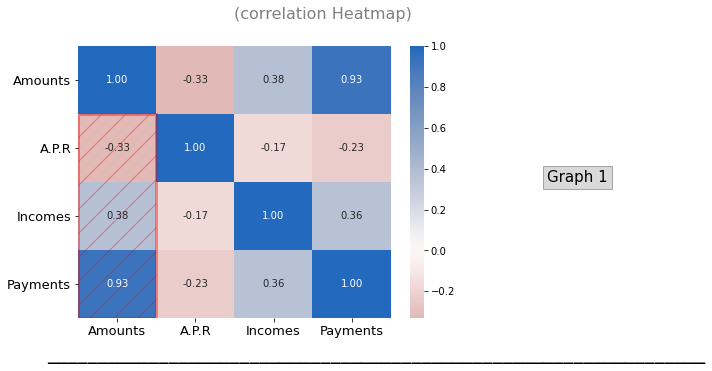

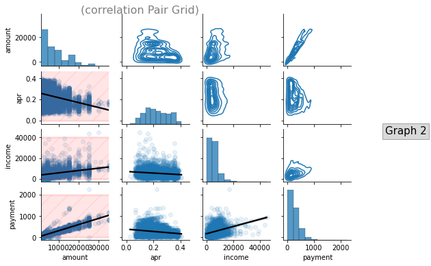

```python
sb.heatmap(df[numerical_col].corr(), annot = True, fmt = '.2f',
           cmap = 'vlag_r', center = 0);
plt.xticks([0.5,1.5,2.5,3.5],['Amounts',  'A.P.R','Incomes', 'Payments'],size=13)
plt.yticks([0.5,1.5,2.5,3.5],['Amounts',  'A.P.R','Incomes', 'Payments'],rotation=0, size=13)
rect = Rectangle((0,4), 1,-3, alpha=0.4 ,fill= False,edgecolor='r',hatch='/',lw=3)
plt.gca().add_patch(rect)
plt.gcf().set_size_inches(7, 5)
plt.text(1.5,0.5, 'Graph 1', transform= plt.gca().transAxes, color='black', fontsize=15, bbox= {'facecolor': 'grey','alpha': 0.3})
plt.text(0.5,1.1, '(correlation Heatmap)', transform= plt.gca().transAxes, color='grey', fontsize=16)
plt.text(-0.1,-0.15, '_'*65, transform= plt.gca().transAxes, color='black', fontsize=20)
plt.show()

g = sb.PairGrid(df_samples[numerical_col])
g.map_diag(sb.histplot, fill=True, color=sb.color_palette()[0], edgecolor="k", linewidth=0.2,bins=10)
g.map_lower(sb.regplot, scatter_kws={'alpha':0.1},line_kws={'color':'black'})
#g.map_upper(sb.scatterplot)
g.map_upper(sb.kdeplot)

rect1 = Rectangle((0,0), 40000,40000, alpha=0.1 ,fill= True,color='r',hatch='/',lw=3,label='fd')
rect2 = Rectangle((0,0), 40000,40000, alpha=0.1 ,fill= True,color='r',hatch='/',lw=3)
rect3 = Rectangle((0,0), 40000,2000, alpha=0.1 ,fill= True,color='r',hatch='/',lw=3)
rect = [rect1,rect2,rect3]
ax=1
for i in rect:
    (g.axes[ax, 0]).add_patch(i)
    ax+=1

plt.gcf().set_size_inches(7, 5)
plt.text(1.5,2, 'Graph 2', transform= plt.gca().transAxes, color='black', fontsize=15, bbox= {'facecolor': 'grey','alpha': 0.3})
plt.text(-3,4.3, '(correlation Pair Grid)', transform= plt.gca().transAxes, color='grey', fontsize=16)
plt.show()
```

# Notes :

> The Heatmap shows the correlation between features with both numbers and color densities to represent both positive and negative relations. The Pair Grid is performed on (25% of data) and with (90% transperancy) to ensure the figure clarity.

# Observations :

> Graph 1 shows that loan amounts has a strong positive relation with payments (93%) wich is logical, also it has a weak positive relation with monthly incomes (38%). and negative relation with loan annual rate (-33%).

> Graph 2 shows a unique three distinct-lines in the relation bet. amounts and payments. also, distinct vertical lines in relations bet. amounts and both apr and incomes. we will invistigate that later.that need further investigations.

## Visualization 18:

## Relation between Loan amounts and A.P.R

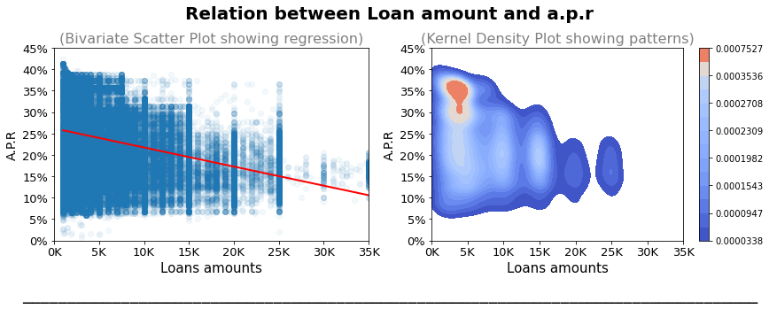

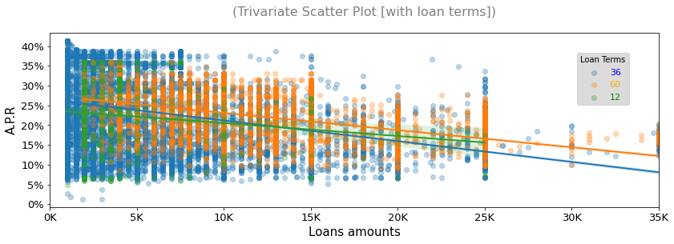

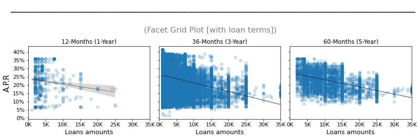

```python
plt.figure(figsize=(14,4))
plt.subplot(1,2,1)
sb.regplot(data= df, x='amount', y='apr', scatter_kws={'alpha': 0.05},line_kws={'color': 'r', 'lw':2})
plt.xlim(0,35000)
plt.ylim(0,0.45)
plt.draw()
locs, labels =plt.yticks()
labels = [str(round(float(x.get_text())*100))+ '%' for x in labels]
plt.yticks(locs, labels, fontsize=13)
locs, labels =plt.xticks()
labels = [str(round(float(x.get_text())/1000))+ 'K' for x in labels]
plt.xticks(locs, labels, fontsize=13)
plt.ylabel('A.P.R', size=14)
plt.xlabel('Loans amounts', size=15)
plt.suptitle('Relation between Loan amount and a.p.r', size=20, fontweight='bold', va='bottom')
plt.title('(Bivariate Scatter Plot showing regression)', size=16, color='grey')
plt.text(-0.1,-0.3, '_'*82, transform= plt.gca().transAxes, color='black', fontsize=20)

plt.subplot(1,2,2)
sb.kdeplot(data= sample, y='apr', x='amount', n_levels=15, shade=True,cmap='coolwarm', cbar=True)
plt.xlim(0,35000)
plt.ylim(0,0.45)
plt.draw()
locs, labels =plt.yticks()
labels = [str(round(float(x.get_text())*100))+ '%' for x in labels]
plt.yticks(locs, labels, fontsize=13)
locs, labels =plt.xticks()
labels = [str(round(float(x.get_text())/1000))+ 'K' for x in labels]
plt.xticks(locs, labels, fontsize=13)
plt.ylabel('A.P.R', size=14)
plt.xlabel('Loans amounts', size=15)
plt.title('(Kernel Density Plot showing patterns)', size=16, color='grey')
plt.show()


g=sb.FacetGrid(data=sample, hue='term',hue_order=df.term.value_counts().index)
g.map(sb.regplot,'amount', 'apr', scatter_kws={'alpha': 0.3},line_kws={'lw':2})
x_ticks= np.arange(0,35001,5000)
g.set(xticks=x_ticks)
g.set_xticklabels([str(round(float(x/1000)))+'K' for x in x_ticks], size=13)
y_ticks= np.arange(0,0.45,0.05)
g.set(yticks=y_ticks)
g.set_yticklabels([str(round(float(x*100)))+'%' for x in y_ticks], size=13)
g.set_ylabels('A.P.R', size=15)
g.set_xlabels('Loans amounts', size=15)
g.despine(top=False, right=False)
plt.gcf().set_size_inches(14, 4)
g.add_legend(bbox_to_anchor=(0.9,0.75),
           bbox_transform=plt.gcf().transFigure,
           title='Loan Terms',
           prop={'size':11},
           labelcolor=['blue', 'orange','green'],
           frameon=True,
           facecolor='lightgray')
plt.text(0.3,1.1, '(Trivariate Scatter Plot [with loan terms])', transform= plt.gca().transAxes, color='grey', fontsize=16);


g=sb.FacetGrid(data=sample, col='term',hue_order=df.term.value_counts().index)
g.map(sb.regplot,'amount', 'apr', scatter_kws={'alpha':0.2}, line_kws={'color':'black','lw':0.5})
x_ticks= np.arange(0,35001,5000)
g.set(xticks=x_ticks)
g.set_xticklabels([str(round(float(x/1000)))+'K' for x in x_ticks], size=11)
y_ticks= np.arange(0,0.45,0.05)
g.set(yticks=y_ticks)
g.set_yticklabels([str(round(float(x*100)))+'%' for x in y_ticks], size=11)
g.set_ylabels('A.P.R', size=15)
g.set_xlabels('Loans amounts', size=13)
g.axes[0,0].set_title('12-Months (1-Year)')
g.axes[0,1].set_title('36-Months (3-Year)')
g.axes[0,2].set_title('60-Months (5-Year)')
g.despine(top=False, right=False)
plt.gcf().set_size_inches(12, 3)
plt.text(-1.2,1.2, '(Facet Grid Plot [with loan terms])', transform= plt.gca().transAxes, color='grey', fontsize=16)
plt.text(-2.3,1.5, '_'*82, transform= plt.gca().transAxes, color='black', fontsize=20)
plt.show()
```

# Notes :